# Spotify Song Success Predictions

Kathleen Phan

2026-07-06

# 1. Introduction

As someone who enjoys listening to many different types of music, I wondered what types of songs are universally considered as “hits”. In this project I seek to answer this question, using audio features from Spotify’s dataset to build predictive models that classify songs as hits (popularity score ≥ 70) or non-hits.

The dataset includes audio features such as danceability, energy, tempo, and valence. I compare four classification models:

- Logistic Regression
- Classification Tree
- Random Forest
- LASSO Regression

# 2. Load Libraries and Data

```r
library(tidyverse)
library(caret)
library(rpart)
library(rpart.plot)
library(randomForest)
library(glmnet)
library(pROC)

# Load data — update filename if yours is different
spotify <- read_csv("spotify-tracks-dataset.csv")
```

# 3. Data Cleaning and Preparation

```r
# Select relevant columns
spotify_clean <- spotify %>%
  select(popularity, danceability, energy, loudness, speechiness,
         acousticness, instrumentalness, liveness, valence, tempo,
         explicit, track_genre) %>%
  drop_na()

# Create binary response variable
spotify_clean <- spotify_clean %>%
  mutate(  # add new 'hit' column
    hit = factor(ifelse(popularity >= 70, "hit", "not_hit")),  #hit = 1 if popularity >= 70
    explicit = factor(explicit)
  ) %>%
  select(-popularity)  # remove popularity since it defines the response

# Check class balance
table(spotify_clean$hit)
```

```
##
##     hit not_hit
##    5472  108528
```

```r
prop.table(table(spotify_clean$hit))
```

```
##
##     hit not_hit
##   0.048   0.952
```

# 4. Exploratory Data Analysis

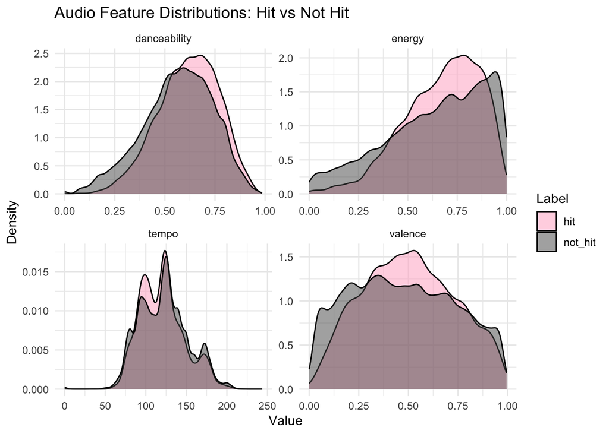

```r
# Distribution of key audio features
spotify_clean %>%
  pivot_longer(cols = c(danceability, energy, valence, tempo),  #reformat columns into rows for ggplot ease
               names_to = "feature", values_to = "value") %>%
  ggplot(aes(x = value, fill = hit)) +
  geom_density(alpha = 0.5) +  # transparent density curve
  facet_wrap(~feature, scales = "free") +  # creates separate plots
  scale_fill_manual(values = c("hit" = "#FFADC7", "not_hit" = "#535353")) +
  labs(title = "Audio Feature Distributions: Hit vs Not Hit",
       x = "Value", y = "Density", fill = "Label") +
  theme_minimal()  #light gridlines, white bkg
```

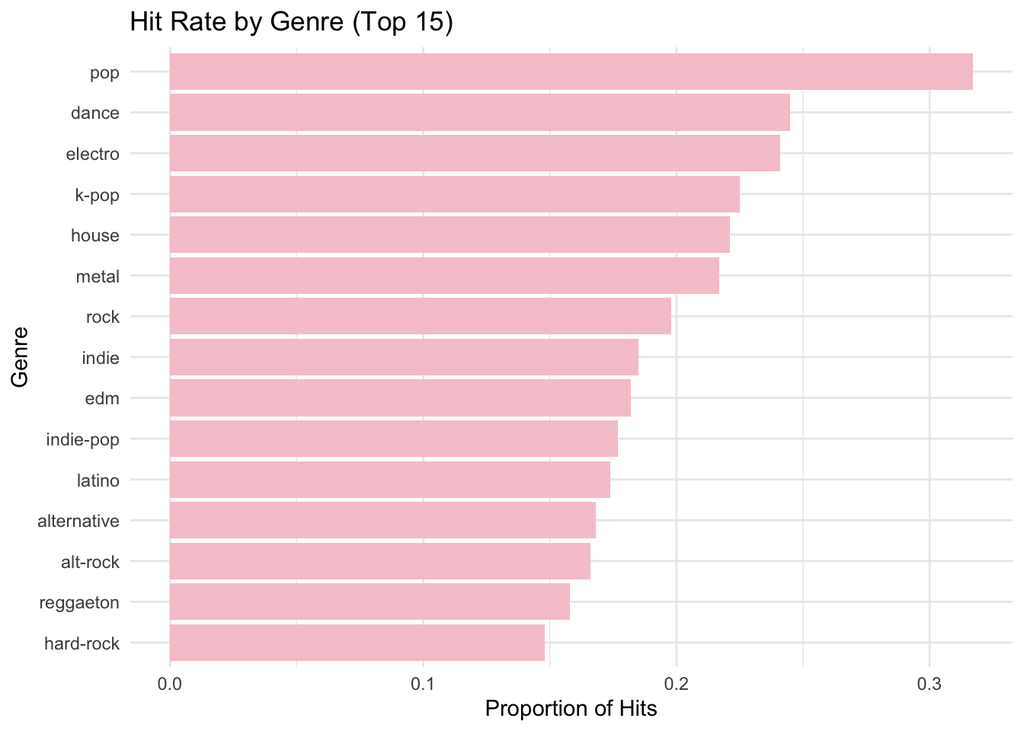

```r
# Hit rate by genre (top 15 genres)
spotify_clean %>%
  group_by(track_genre) %>%
  summarise(hit_rate = mean(hit == "hit"), count = n()) %>%
  filter(count >= 100) %>%
  arrange(desc(hit_rate)) %>%
  slice_head(n = 15) %>%
  ggplot(aes(x = reorder(track_genre, hit_rate), y = hit_rate)) +
  geom_col(fill = "#F6C8D1") +
  coord_flip() +  # flip x and y, helps readability
  labs(title = "Hit Rate by Genre (Top 15)",
       x = "Genre", y = "Proportion of Hits") +
  theme_minimal()
```

```r
# Correlation between numeric features
spotify_clean %>%
  select(where(is.numeric)) %>%
  cor() %>%
  round(2)
```

```
##                  danceability energy loudness speechiness acousticness
## danceability             1.00   0.13     0.26        0.11        -0.17
## energy                   0.13   1.00     0.76        0.14        -0.73
## loudness                 0.26   0.76     1.00        0.06        -0.59
## speechiness              0.11   0.14     0.06        1.00         0.00
## acousticness            -0.17  -0.73    -0.59        0.00         1.00
## instrumentalness        -0.19  -0.18    -0.43       -0.09         0.10
## liveness                -0.13   0.18     0.08        0.21        -0.02
## valence                  0.48   0.26     0.28        0.04        -0.11
## tempo                   -0.05   0.25     0.21        0.02        -0.21
##                  instrumentalness liveness valence tempo
## danceability                -0.19    -0.13    0.48 -0.05
## energy                      -0.18     0.18    0.26  0.25
## loudness                    -0.43     0.08    0.28  0.21
## speechiness                 -0.09     0.21    0.04  0.02
## acousticness                 0.10    -0.02   -0.11 -0.21
## instrumentalness             1.00    -0.08   -0.32 -0.05
## liveness                    -0.08     1.00    0.02  0.00
## valence                     -0.32     0.02    1.00  0.08
## tempo                       -0.05     0.00    0.08  1.00
```

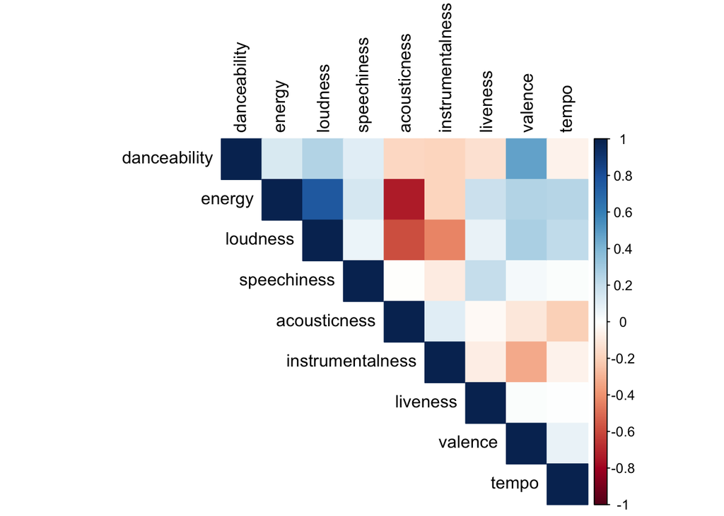

```r
library(corrplot)
spotify_clean %>%
  select(where(is.numeric)) %>%
  cor() %>%
  corrplot(method = "color", type = "upper", tl.col = "black")
```

# 5. Train/Test Split

```r
set.seed(123)

train_index <- createDataPartition(spotify_clean$hit, p = 0.8, list = FALSE)  # split data into 80% training 20% test
train_data  <- spotify_clean[train_index, ]
test_data   <- spotify_clean[-train_index, ]
```

# 6.1 Logistic Regression

```r
log_model <- glm(hit ~ . - track_genre,
                 data = train_data,
                 family = binomial)
summary(log_model)
```

```
##
## Call:
## glm(formula = hit ~ . - track_genre, family = binomial, data = train_data)
##
## Coefficients:
##                    Estimate Std. Error z value Pr(>|z|)
## (Intercept)       0.3882853  0.1768183   2.196   0.0281 *
## danceability     -0.9956285  0.1203428  -8.273  < 2e-16 ***
## energy            1.6663090  0.1411412  11.806  < 2e-16 ***
## loudness         -0.1057524  0.0078564 -13.461  < 2e-16 ***
## speechiness       2.2516397  0.2330329   9.662  < 2e-16 ***
## acousticness      1.2332607  0.0798707  15.441  < 2e-16 ***
## instrumentalness  2.0937350  0.1134331  18.458  < 2e-16 ***
## liveness          1.4049866  0.1162560  12.085  < 2e-16 ***
## valence           0.1912752  0.0772020   2.478   0.0132 *
## tempo             0.0028675  0.0005801   4.943 7.68e-07 ***
## explicitTRUE     -0.5847103  0.0473594 -12.346  < 2e-16 ***
## ---
## Signif. codes:  0 '***' 0.001 '**' 0.01 '*' 0.05 '.' 0.1 ' ' 1
##
## (Dispersion parameter for binomial family taken to be 1)
##
##     Null deviance: 35130  on 91200  degrees of freedom
## Residual deviance: 32807  on 91190  degrees of freedom
## AIC: 32829
##
## Number of Fisher Scoring iterations: 7
```

```r
# Predictions
log_probs <- predict(log_model, test_data, type = "response")  # assigns a probability to each set of predictors based on the logistic model
log_preds <- factor(ifelse(log_probs > 0.5, "hit", "not_hit"))  # matchs prob to corresponding response

# Confusion matrix
confusionMatrix(log_preds, test_data$hit, positive = "hit")
```

```
## Confusion Matrix and Statistics
##
##           Reference
## Prediction   hit not_hit
##    hit      1094   21705
##    not_hit     0       0
##
##                Accuracy : 0.048
##                  95% CI : (0.0452, 0.0508)
##     No Information Rate : 0.952
##     P-Value [Acc > NIR] : 1
##
##                   Kappa : 0
##
##  Mcnemar's Test P-Value : <2e-16
##
##             Sensitivity : 1.00000
##             Specificity : 0.00000
##          Pos Pred Value : 0.04798
##          Neg Pred Value :     NaN
##              Prevalence : 0.04798
##          Detection Rate : 0.04798
##    Detection Prevalence : 1.00000
##       Balanced Accuracy : 0.50000
##
##        'Positive' Class : hit
##
```

# 6.2 Classification Tree

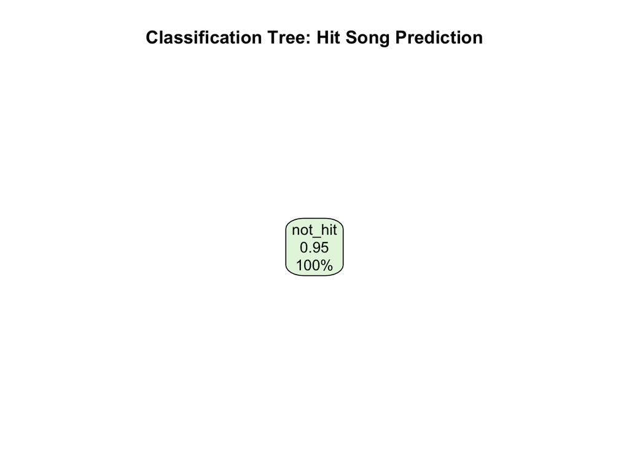

```r
tree_model <- rpart(hit ~ . - track_genre,
                    data = train_data,
                    method = "class")

# Plot tree
rpart.plot(tree_model, main = "Classification Tree: Hit Song Prediction")
```

```r
# Predictions
tree_preds <- predict(tree_model, test_data, type = "class")  # response predictions

# Confusion matrix
confusionMatrix(tree_preds, test_data$hit, positive = "hit")
```

```
## Confusion Matrix and Statistics
##
##           Reference
## Prediction   hit not_hit
##    hit         0       0
##    not_hit  1094   21705
##
##                Accuracy : 0.952
##                  95% CI : (0.9492, 0.9548)
##     No Information Rate : 0.952
##     P-Value [Acc > NIR] : 0.508
##
##                   Kappa : 0
##
##  Mcnemar's Test P-Value : <2e-16
##
##             Sensitivity : 0.00000
##             Specificity : 1.00000
##          Pos Pred Value :     NaN
##          Neg Pred Value : 0.95202
##              Prevalence : 0.04798
##          Detection Rate : 0.00000
##    Detection Prevalence : 0.00000
##       Balanced Accuracy : 0.50000
##
##        'Positive' Class : hit
##
```

```r
set.seed(123)
train_balanced <- downSample(x = train_data %>% select(-hit),  #randomly remove rows from 'hit' until same size as 'not hit'
                             y = train_data$hit,
                             yname = "hit")

# Check balance
table(train_data$hit)
```

```
##
##     hit not_hit
##    4378   86823
```

```r
table(train_balanced$hit)
```

```
##
##     hit not_hit
##    4378    4378
```

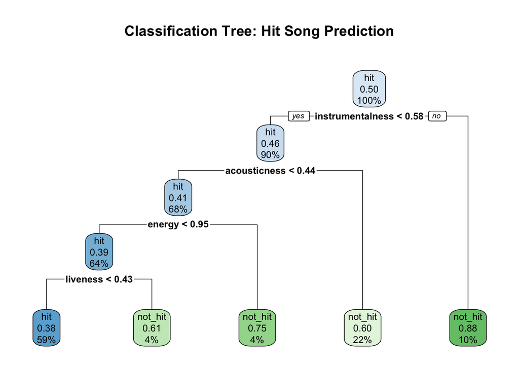

```r
# Refit tree using balanced data
tree_model <- rpart(hit ~ . - track_genre,
                    data = train_balanced,
                    method = "class")

rpart.plot(tree_model, main = "Classification Tree: Hit Song Prediction")
```

# 6.3 Random Forest

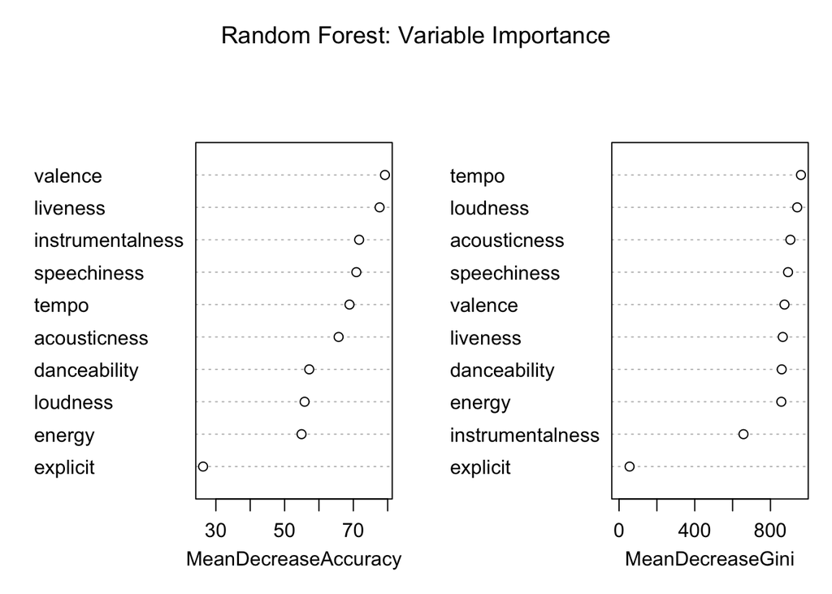

```r
set.seed(123)
rf_model <- randomForest(hit ~ . - track_genre,
                         data = train_data,
                         ntree = 100,
                         importance = TRUE)

# Variable importance
varImpPlot(rf_model, main = "Random Forest: Variable Importance")
```

```r
# Predictions
rf_preds <- predict(rf_model, test_data)
rf_probs <- predict(rf_model, test_data, type = "prob")[, "hit"]

# Confusion matrix
confusionMatrix(rf_preds, test_data$hit, positive = "hit")
```

```
## Confusion Matrix and Statistics
##
##           Reference
## Prediction   hit not_hit
##    hit       669      63
##    not_hit   425   21642
##
##                Accuracy : 0.9786
##                  95% CI : (0.9766, 0.9804)
##     No Information Rate : 0.952
##     P-Value [Acc > NIR] : < 2.2e-16
##
##                   Kappa : 0.7221
##
##  Mcnemar's Test P-Value : < 2.2e-16
##
##             Sensitivity : 0.61152
##             Specificity : 0.99710
##          Pos Pred Value : 0.91393
##          Neg Pred Value : 0.98074
##              Prevalence : 0.04798
##          Detection Rate : 0.02934
##    Detection Prevalence : 0.03211
##       Balanced Accuracy : 0.80431
##
##        'Positive' Class : hit
##
```

# 6.4 LASSO Regression

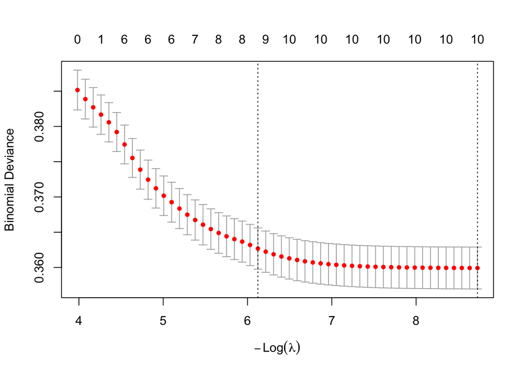

```r
# Prepare matrix format for glmnet
x_train <- model.matrix(hit ~ . - track_genre, train_data)[, -1]
y_train <- ifelse(train_data$hit == "hit", 1, 0)

x_test  <- model.matrix(hit ~ . - track_genre, test_data)[, -1]

# Cross-validated LASSO
set.seed(123)
lasso_cv <- cv.glmnet(x_train, y_train, alpha = 1, family = "binomial")

# Best lambda
plot(lasso_cv)
```

```r
bestlam=lasso_cv$lambda.min #choose lowest lambda
bestlam
```

```
## [1] 0.0001619562
```

```r
# Predictions
lasso_probs <- predict(lasso_cv, x_test, s = "lambda.min", type = "response")
lasso_preds <- factor(ifelse(lasso_probs > 0.5, "hit", "not_hit"))

# Confusion matrix
confusionMatrix(lasso_preds, test_data$hit, positive = "hit")
```

```
## Confusion Matrix and Statistics
##
##           Reference
## Prediction   hit not_hit
##    hit         0       0
##    not_hit  1094   21705
##
##                Accuracy : 0.952
##                  95% CI : (0.9492, 0.9548)
##     No Information Rate : 0.952
##     P-Value [Acc > NIR] : 0.508
##
##                   Kappa : 0
##
##  Mcnemar's Test P-Value : <2e-16
##
##             Sensitivity : 0.00000
##             Specificity : 1.00000
##          Pos Pred Value :     NaN
##          Neg Pred Value : 0.95202
##              Prevalence : 0.04798
##          Detection Rate : 0.00000
##    Detection Prevalence : 0.00000
##       Balanced Accuracy : 0.50000
##
##        'Positive' Class : hit
##
```

# 7. Model Comparison

```r
# Function to extract metrics
get_metrics <- function(preds, actual) {
  cm <- confusionMatrix(preds, actual, positive = "hit")
  data.frame(
    Accuracy    = round(cm$overall["Accuracy"], 3),
    Sensitivity = round(cm$byClass["Sensitivity"], 3),
    Specificity = round(cm$byClass["Specificity"], 3),
    Precision   = round(cm$byClass["Pos Pred Value"], 3)
  )
}

# Combine all models
results <- data.frame(
  Model = c("Logistic", "Classification Tree", "Random Forest", "LASSO"),
  rbind(
    get_metrics(log_preds,   test_data$hit),
    get_metrics(tree_preds,  test_data$hit),
    get_metrics(rf_preds,    test_data$hit),
    get_metrics(lasso_preds, test_data$hit)
  )
)

rownames(results) <- NULL  # construct data frame
results
```

```
##                 Model Accuracy Sensitivity Specificity Precision
## 1            Logistic    0.048       1.000       0.000     0.048
## 2 Classification Tree    0.952       0.000       1.000       NaN
## 3       Random Forest    0.979       0.612       0.997     0.914
## 4               LASSO    0.952       0.000       1.000       NaN
```

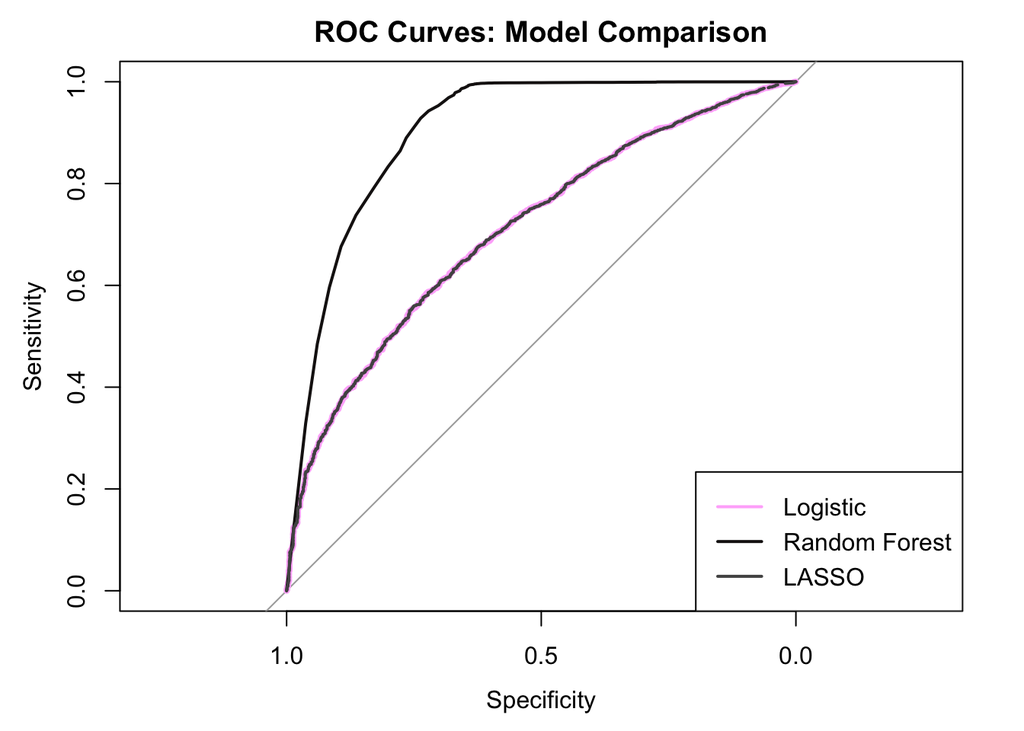

```r
# ROC curves
roc_log   <- roc(test_data$hit, log_probs)
roc_rf    <- roc(test_data$hit, rf_probs)
roc_lasso <- roc(test_data$hit, as.vector(lasso_probs))

plot(roc_log,   col = "#FFB3FA", lwd=4, main = "ROC Curves: Model Comparison")
plot(roc_rf,    col = "#191414", add = TRUE)
plot(roc_lasso, col = "#535353", add = TRUE, lty = 2)
legend("bottomright",
       legend = c(paste("Logistic"),
                  paste("Random Forest"),
                  paste("LASSO")),
       col = c("#FFB3FA", "#191414", "#535353"),
       lwd = 2)
```

# 8. Key findings

**Limitations:**

- “Hit” is defined by an arbitrary popularity threshold of 70.
- The dataset may not reflect current trends, nor a wide range of different user preferences. This project investigates a very general, Western audience.
- The class imbalance of disproportionately more non-hits than hits affected model performance. This explains why models such as classification trees and lasso has sensitivity scores of 0. These models over-predicted non-hits.

**Future work:**

- Investigate difference audiences from difference countries
- Try genre-specific models to see if what makes a hit differs by genre